# LitOver T. parvula

Evelia Coss

4/27/2020

## Creando un archivo de anotacion de *T. parvula*

La especie *T. parvula* cuenta con dos versiones en su genoma: **v1 (proveniente de NCBI)** y **v2 (proveniente de una organizacion http://thellungiella.org/data/)**. Sin embargo, solo existe un archivo de anotacion, el cual corresponde a la v2, la cual se encuentra fragmentada en mas de dos mil fragmentos. Cuando la version de NCBI se encuentra distribuida en tan solo 7 cromosomas.

Por lo anterior, se decidio generar un nuevo archivo de anotacion empleando la herramienta **liftOver**. Esta herramienta genera un nuevo archivo de anotacion a partir de dos genomas existentes y un archivo de anotacion previo. Se empleo el script encontrado para [liftOver](https://iamphioxus.org/tag/liftover/) con algunas modificaciones.

*Nota* = Los siguientes script fueron ejecutados en mazorka, empleando el modulo **kenUtils/v302** y **blat/36**.

#### 1.- Crear sym link de los genomas

Se determino que el G1 y G2 serian la version 2 y version 1, respectivamente. Por lo que, posteriomente, se genero un sym link de cada genoma con el fin de facilitar su manipulacion en el script.

```bash
# G1.fa
ln -s /LUSTRE/usuario/ecoss/raw_data/genomes/josian/Thellungiella_parvula_v2.fa G1.fa

#G2.fa
ln -s /LUSTRE/usuario/ecoss/raw_data/genomes/josian/Schrenkiella-parvula_eutrema-parvulum_v01.genome.fa G2.fa
```

#### 2.-Fragmentar el G2 en cromosomas

El G2 se fragmento con base en el numero de cromosomas, es decir, en 7 fragmentos mediante la herramienta **faSplit sequence**. A continuacion, se muestra el script empleado.

```bash
chr_num=$(cat G2.fa | grep '>' | wc -l) #numero de cromosomas (7)
faSplit sequence G2.fa $chr_num G2_
```

#### 3.- Correr script

El script primero fue evaluado individualmente por cada paso, para posteriormente emplear en un archivo *.sh* en mazorka.

```bash
#PBS -N LiftOver_complete
#PBS -q default
#PBS -l nodes=1:ppn=1,vmem=18gb,walltime=200:00:00
#PBS -V
#PBS -o Lc.out
#PBS -e Lc.err

#archivos previamente generados de chr-CM
# G1 = ln -s /LUSTRE/usuario/ecoss/raw_data/genomes/josian/Thellungiella_parvula_v2.fa G1.fa
# G2 = ln -s /LUSTRE/usuario/ecoss/raw_data/genomes/josian/Schrenkiella-parvula_eutrema-parvulum_v01.genome.fa G2.fa

#cargar modulos
module load kenUtils/v302
module load blat/36

#Ubicacion
cd $PBS_O_WORKDIR
#1.- Split the G2 chromosomes/scaffolds into 3K chunks and make lift files
for i in {0..6}
    do
    faSplit size G2_${i}.fa 3000 G2.${i}.split -lift=G2.${i}.lft -oneFile
    done

#2.- run blat
for i in {0..6}
    do
    blat G1.fa G2.${i}.split.fa -t=dna -q=dna -tileSize=12 -fastMap -minIdentity=95 -noHead -minScore=100 G2.${i}.psl
    done

#3.- Change coordinates of .psl files to parent coordinate system
for i in {0..6}
    do
    liftUp -pslQ G2.${i}.liftup.psl G2.${i}.lft warn G2.${i}.psl
    done

#4.-  Make chain files
for i in {0..6}
    do
    axtChain -linearGap=medium -faQ -faT -psl G2.${i}.liftup.psl G1.fa G2.fa ${i}.chain
    done
#5.- Merge and sort chain files
chainMergeSort *.chain | chainSplit chain_split stdin

faSize "G1.fa" -detailed >G1.chr_length.txt
faSize "G2.fa" -detailed >G2.chr_length.txt

# 6.-  Make alignment nets from chain files***
mkdir net
for i in ./chain_split/*.chain
    do
    tag=${i/\.\/chain_split\//}
    chainNet $i ./G1.chr_length.txt ./G2.chr_length.txt ./net/$tag.net /dev/null
    done

#7.- Create liftOver chain file
mkdir over
for i in ./chain_split/*.chain
    do
    tag=${i/\.\/chain_split\//}
    netChainSubset ./net/${tag}.net $i ./over/${tag}.chain
    done

cat ./over/*.chain >G1_G2.over.chain
```

El archivo **G1_G2.over.chain** nos permite comparar el archivo de anotacion de la v2 con el genoma v1, y con esto poder generar un nuevo archivo de anotacion. Para lo cual, necesitamos el archivo de anotacion de la v2 en formato BED.

#### 4.-Restauracion del archivo de anotacion v2 y conversion a BED

El archivo de anotacion orginal v2 no contiene **gene_id**, solo contiene **transcript_id**. Por lo que, Dr. Victor Flores (postoc de SAGARPA y de la Dra. Selene) me ayudo a modificar este archivo mediante el siguiente script.

```bash
awk 'BEGIN{FS="\t"}{print $AF" gene_id \""$9"\";"}' Thellungiella_parvula_v2.gtf | perl -pe 's/\"transcript_id\ //;s/\"\;$//' > Thellungiella_parvula_v2.test.gtf
```

Posteriormente, se descargaron los programas **gtfToGenePred** y **genePredToBed**, siguiendo las instrucciones del siguiente [link](https://gist.github.com/gireeshkbogu/f478ad8495dca56545746cd391615b93) y se conviertieron en ejecutable.

```bash
chmod +x gtfToGenePred genePredToBed
```

A continuacion, se muestra el script empleado para la conversion de formato GTF a BED.

```bash
# Convert Gtf to genePred

for file in *.gtf;  do clean=$(echo $file | sed 's/\.gtf//'); ./gtfToGenePred $file ${clean}.genePred; done

# Convert genPred to bed12

for file in *.genePred;  do clean=$(echo $file | sed 's/\.genePred//'); ./genePredToBed $file ${clean}.bed12; done

# sort bed12
$ for file in *.bed12; do clean=$(echo $file | sed 's/\.bed12//'); sort -k1,1 -k2,2n $file > ${clean}.sorted.bed; done
```

#### 5.- LiftOver

Finalmente, se realizo el **liftover** con los archivos previamente obtenidos. Mediante **liftover** obtenemos un nuevo archivo de anotacion para la version 1 del genoma de *T. parvula*.

```bash
#8.- Ultimo paso
liftOver Thellungiella_parvula_v2.test.sorted.bed G1_G2.over.chain G2_conversion.bed unMapped
```

Posteriormente, descargue el archivo **G2_conversion.bed** en mi computadora a traves del siguiente script y se realizo la conversion del formato BED a GTF.

```bash
rsync -azvh --partial --progress ecoss@mazorka.langebio.cinvestav.mx:"/LUSTRE/usuario/ecoss/raw_data/annotation/chr-CM_data/G2_conversion.bed" .

# Conversion de BED a GTF
./bedToGenePred G2_conversion.bed G3.genePred
./genePredToGTF "file" G3.genePred G3.gtf
```

*Nota*= La conversion de BED a GTF tambien se puede realizar en mazorka a traves del modulo **kenUtils/v302**

Y se subio a mazorka, a traves del siguiente script.

```bash
rsync -av G3.gtf ecoss@mazorka.langebio.cinvestav.mx:"/LUSTRE/usuario/ecoss/raw_data/annotation/chr-CM_data"
```

#### 6.- Evaluacion del nuevo archivo de anotacion (G3.gtf)

**6.1.-Comparacion visual entre genomas y archivos de anotacion**

Se realizo una comparacion visual de los archivos de anotacion.

```bash
head G1.gtf G3.gtf | less -S
```

Donde **G1.gtf** es el archivo de anotacion original (genoma v2) y **G3.gtf** el nuevo (genoma v1). Encontrando la conservacion de los **gene_id** en nuestro nuevo archivo de anotacion, lo cual es bueno. Ademas, de encontrar un mayor numero de elementos en este nuevo archivo como son la identificacion de: transcript, star_codon y stop_codon.

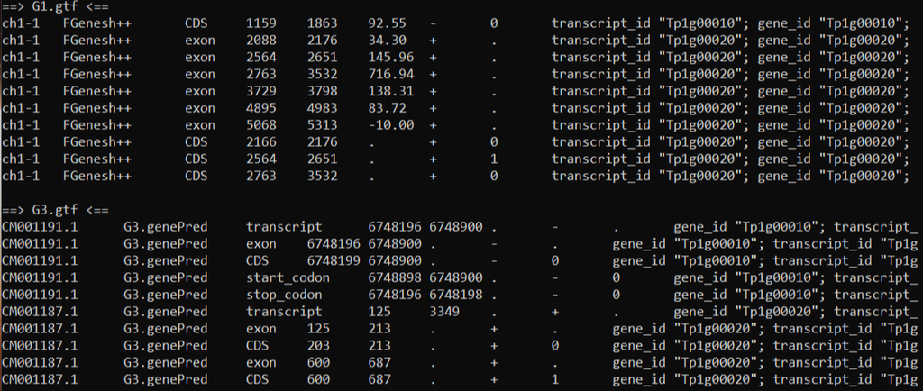

Ademas, se visualizaron los archivos de anotacion en el IGV. Comparando el genoma v1 con el nuevo archivo de anotacion y el genoma v2 con el archivo de anotacion viejo.

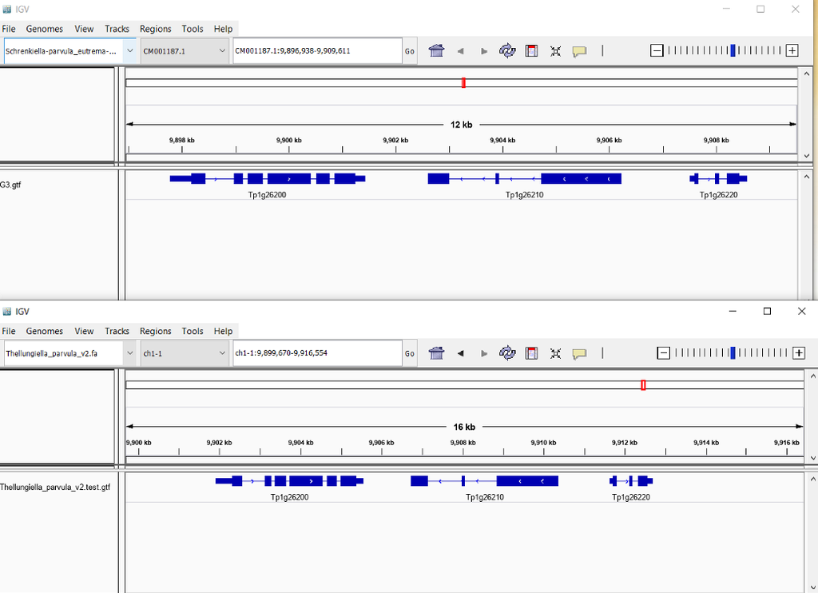

**6.2.-Comparacion de secuencias de aminoacidos a traves del CDS**

*Nota* = Los siguientes pasos se realizaron en Marzoka.

- 1.- Obtener los CDS de los archivos de anotacion (GTF)

```bash
#Archivo de anotacion original
cat G1.gtf | grep 'CDS' > G1_CDS.gtf

#Archivo de anotacion nuevo
cat G3.gtf | grep 'CDS' > G3_CDS.gtf
```

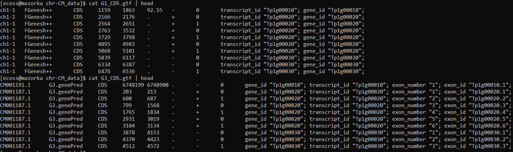

Para conocer el numero total de secuencias contenidas en los diferentes archivos de anotacion se emplearon los siguientes comandos:

```bash
#Cuantas secuencias se encuentran contenidas en el archivo de anotacion original?
cat G1_CDS.gtf | wc -l

#cuantas secuencias se encuentran en el archivo de anotacion nuevo?
cat G3_CDS.gtf | wc -l

#Cuantas secuencias no mapearon con el nuevo archivo de anotacion?
cat unMapped | grep '#' | wc -l
```

Hasta el momento tenemos:

| Archivo | No. secuencias |
| --- | --- |
| G1_CDS.gtf | 141785 |
| G3_CDS.gtf | 134020 |
| unMapped | 2080 |

*Nota* = En el caso de unMapped se cuantificaron los parametros empleados para descargar las secuencias, senalados con el simbolo #.

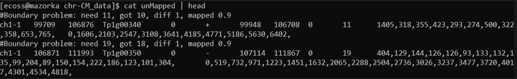

- 2.- Convertir de GTF a BED y seleccionar 10 genes para evaluacion

```bash
# Convertir de Gtf a genePred
for file in G1_CDS.gtf;  do clean=$(echo $file | sed 's/\.gtf//'); gtfToGenePred $file ${cl
ean}.genePred; done

for file in G3_CDS.gtf;  do clean=$(echo $file | sed 's/\.gtf//'); gtfToGenePred $file ${cl
ean}.genePred; done

# Convertir de genPred a bed12
for file in *.genePred;  do clean=$(echo $file | sed 's/\.genePred//'); ./genePredToBed $file ${clean}.bed12; done

# Ordenar los archivos bed12
for file in *.bed12; do clean=$(echo $file | sed 's/\.bed12//'); sort -k1,1 -k2,2n $file > ${clean}.sorted.bed; done
```

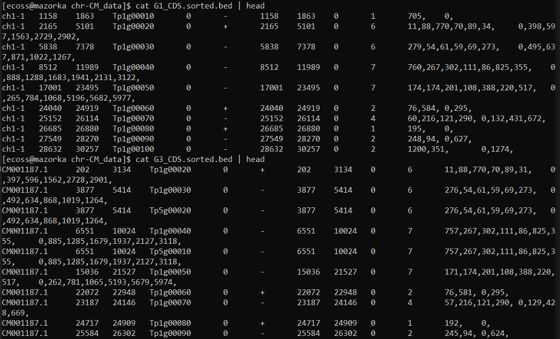

Se seleccionaron los primeros 3 genes del cromosoma 1-1, 3 genes del cromosoma 2-1, 3 genes del cromosoma 3-1 y el primer gen del cromosoma 7-6 del archivo de anotacion original.

```bash
# Archivo de anotacion original
cat G1_CDS.sorted.bed | head -3 > test.bed
cat G1_CDS.sorted.bed |grep 'ch2-1' | head -3 >> test.bed
cat G1_CDS.sorted.bed |grep 'ch3-1' | head -3 >> test.bed
cat G1_CDS.sorted.bed |grep 'ch7-6' | head -1 >> test.bed
cat test.bed
```

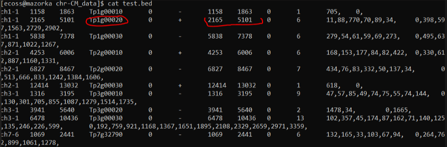

*Nota* = Lo que se encuentra senalado en rojo es una referencia que los CDS del gen Tp1g00020 se agruparon en un solo punto de coordenadas.

Posteriormente, con los mismos gene_id del archivo de anotacion original de los 10 genes seleccionados. Se capturaron los genes y se colocaron en un nuevo archivo.

```bash
# Archivo de anotacion nuevo
cat G3_CDS.sorted.bed | grep 'Tp1g00010' > test.newversion.bed
cat G3_CDS.sorted.bed | grep 'Tp1g00010' >> test.newversion.bed
cat G3_CDS.sorted.bed | grep 'Tp1g00030' >> test.newversion.bed
cat G3_CDS.sorted.bed | grep 'Tp1g00030' >> test.newversion.bed
cat G3_CDS.sorted.bed | grep 'Tp2g00020' >> test.newversion.bed
cat G3_CDS.sorted.bed | grep 'Tp2g00030' >> test.newversion.bed
cat G3_CDS.sorted.bed | grep 'Tp3g00010' >> test.newversion.bed
cat G3_CDS.sorted.bed | grep 'Tp3g00020' >> test.newversion.bed
cat G3_CDS.sorted.bed | grep 'Tp3g00030' >> test.newversion.bed
cat G3_CDS.sorted.bed | grep 'Tp7g32790' >> test.newversion.bed
```

[figure not shown]

*Nota* = en rojo se senala el mismo gen analizado en el archivo de anotacion original.

- 3.- Instalar bedtools y obtener secuencias con getfasta

Se descargo el archivo **bedtools.static.binary** del siguiente [link](https://github.com/arq5x/bedtools2/releases). Se le cambio el nombre al archivo por **bedtools** y se convirtio el archivo en ejecutable.

*Nota* = Los siguientes pasos se realizaron en mi computadora.

```bash
mv bedtools.static.binary bedtools
chmod a+x bedtools
```

En el [manual](https://bedtools.readthedocs.io/en/latest/content/tools/getfasta.html) de **getfasta** describe el empleo de archivos BED, previamente generados, recomendando que los nombres en el FASTA concuerden con los del BED.

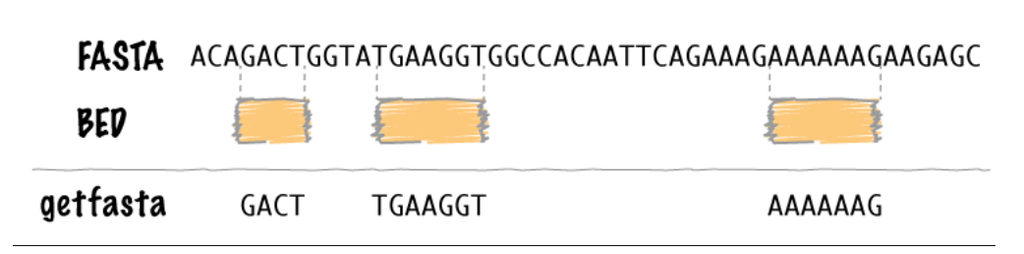

Posteriormente, se descargaron los archivos test.bed y test.newversion.bed a mi compuradora. Y se extrajeron las secuencias por medio de **getfasta**, empleando el genoma (FASTA) y archivo de anotacion (BED). Esto se realizo tanto con el archivo de anotacion original como con el nuevo.

```bash
#Archivo de anotacion original
./bedtools getfasta -fi Thellungiella_parvula_v2.fa -bed  test.bed -split -name >test_genes.fa
cat test_genes.fa | grep '>'

#Archivo de anotacion nueva
./bedtools getfasta -fi Schrenkiella-parvula_eutrema-parvulum_v01.genome.fa -bed  test.newversion.bed -split -name > test_newversion.fa
cat test_newversion.fa |grep '>'
```

Obteniendo los siguientes gene_id en los archivos:

| Archivo de anotacion origina | Archivo de anotacion nueva |
| --- | --- |
| >Tp1g00010::ch1-1:1158-1863 | >Tp1g00010::CM001191.1:6748198-6748900 |
| >Tp1g00020::ch1-1:2087-5313 | >Tp1g00020::CM001187.1:202-3134 |
| >Tp1g00030::ch1-1:5564-7378 | >Tp1g00030::CM001187.1:3877-5414 |
| >Tp2g00010::ch2-1:4253-6387 | >Tp2g00010::CM001188.1:4253-6003 |
| >Tp2g00020::ch2-1:6701-8486 | >Tp2g00020::CM001188.1:6830-8467 |
| >Tp2g00030::ch2-1:12414-13032 | >Tp2g00030::CM001188.1:12414-13029 |
| >Tp3g00010::ch3-1:1147-5419 | >Tp3g00010::CM001189.1:1319-3195 |
| >Tp3g00020::ch3-1:3051-5670 | >Tp3g00020::CM001189.1:3944-5640 |
| >Tp3g00030::ch3-1:6323-10707 | >Tp3g00030::CM001189.1:6481-10436 |
| >Tp7g32790::ch7-6:1069-2441 | >Tp7g32790::CM001193.1:17053539-17054908 |

Debido que los nombres contienen **::** en sus nombres, necesitamos eliminar estos caracteres debido que los programas de EMBOSS emplean estos caracteres para denotar un archivo de salida (>) y al contenerlos genera cambios en el nombre de los archivos. Para lo cual, Victor nos dio el siguiente codigo para ambos archivos de anotacion.

```bash
#Archivo de anotacion original
perl -pe 's/\:\:/\ /g' test_genes.fa > test_genes.fasta
cat test_genes.fasta | grep '>'

#Archivo de anotacion nuevo
perl -pe 's/\:\:/\ /g' test_newversion.fa > test_newversion.fasta
cat  test_newversion.fasta | grep '>'
```

Los nuevos nombres de nuestros archivos son los siguientes:

| Archivo de anotacion origina | Archivo de anotacion nueva |
| --- | --- |
| >Tp1g00010 ch1-1:1158-1863 | >Tp1g00010 CM001191.1:6748198-6748900 |
| >Tp1g00020 ch1-1:2087-5313 | >Tp1g00020 CM001187.1:202-3134 |
| >Tp1g00030 ch1-1:5564-7378 | >Tp1g00030 CM001187.1:3877-5414 |
| >Tp2g00010 ch2-1:4253-6387 | >Tp2g00010 CM001188.1:4253-6003 |
| >Tp2g00020 ch2-1:6701-8486 | >Tp2g00020 CM001188.1:6830-8467 |
| >Tp2g00030 ch2-1:12414-13032 | >Tp2g00030 CM001188.1:12414-13029 |
| >Tp3g00010 ch3-1:1147-5419 | >Tp3g00010 CM001189.1:1319-3195 |
| >Tp3g00020 ch3-1:3051-5670 | >Tp3g00020 CM001189.1:3944-5640 |
| >Tp3g00030 ch3-1:6323-10707 | >Tp3g00030 CM001189.1:6481-10436 |
| >Tp7g32790 ch7-6:1069-2441 | >Tp7g32790 CM001193.1:17053539-17054908 |

- 4.- Convertir las secuencias a aminoacidos por medio de **transeq**

Para conocer si existieron deleciones importantes en nuestras secuencias al realizar el liftover, se convirtieron las secuencias nucleotidicas a aminoacidos por medio de **transeq**, programa de EMBOSS. Para mas informacion consultar el [manual](http://emboss.open-bio.org/rel/rel6/apps/transeq.html).

```bash
#Anotacion orginal
transeq -sequence test_genes.fasta -outseq test_genes.pep -frame=1

#Anotacion nueva
transeq -sequence test_newversion.fasta -outseq test_newversion.pep -frame=1
```

- 5.- Comparacion de secuencias de aminoacidos por medio de **makeblastdb** y **blastp**

Victor me explico que **makeblastdb** es conveniente ser empleado para los genes contenidos en el archivo de anotacion original, para posteriormente, comparar ambos archivos con el **blastp**. Senalando el parametro *query* para aquel archivo de anotacion del cual no tenemos la certeza del 100% que se encuentre bien, en nuetro caso los 10 genes obtenidos del nuevo archivo de anotacion.

Mediante estos analisis buscamos identificar deleciones, inserciones o posibles cambios de lectura que pudieran afectar la funcion de las proteinas producto del liftOver.

Para lo cual, primero se descargo el archivo **ncbi-blast-2.10.0+-x64-linux.tar.gz** del siguiente link. Se descomprimio el archivo y se exporto al $PATH.

```bash
#1.- Descomprimir el archivo
tar -zxvf ncbi-blast-2.10.0+-x64-linux.tar.gz
#2.- Exportarlo al $PATH
export PATH="/mnt/c/Users/eveli/'OneDrive - CINVESTAV'/Documentos/'DOCTORADO con SLFV y KOS/Todo sobre RNA-seq'/over/ncbi-blast-2.10.0+/bin:$PATH"
```

Posteriormente, se realizo el **makeblastdb** con los 10 genes obtenidos por medio del archivo de anotacion viejo.

```bash
makeblastdb -in test_genes.pep -title test_genes.pep -dbtype prot
```

Finalmente, se realizo una comparacion con las secuencias de aminoacidos entre el archivo de anotacion nuevo y el original por medio de **blastp**.

```bash
blastp -query test_newversion.pep -db test_genes.pep -out lifted.blastp -outfmt "6 qseqid sseqid qlen slen qstart sstart qend send score evalue length positive" -evalue 1e-10
```

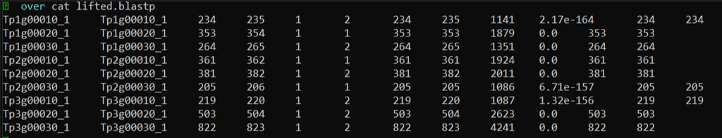

Nuestro resultado indica la perdida de un codon entre las secuencias evaluadas, el cual puede o no ser suficiente para afectar la funcion de una proteina. En general, nuestro nuevo archivo de anotacion puede ser empleado para los pasos siguientes en el analisis. (: